# ch1: EDA

Steve Newns

May 7, 2018

### Exploratory Data Analysis

In Contrast to the purely theoretical nature of **probability**: **statistics** = an *applied* science concerned w/ analysis + modeling of data

EDA = comparatively new area of statistics, as classical statistics focused almost exclusively on **inference** = sometimes complex set of procedures for drawing conclusions about large populations based on small samples

1962: Tukey = “The Future of Data Analysis” = proposed new scientific discipline: **data analysis** = included statistical inference as just 1 component, forging links tothe engineering + CS communities (terms like **bit** (short for binary digit) + software)

Field of EDA = established with Tukey’s 1977 now-classic book **Exploratory Data Analysis**, w/ key drivers of this discipline = rapid development of new tech, access to more + bigger data, + greater use of quantitative analysis in a variety of disciplines

Major challenge of data science: to harness torrent of raw data into actionable information so as to apply statistical concepts

Data type = important to help determine the type of visual display, data analysis, or statistical model:

- Structured
- numeric
  - continuous vs. discrete
- categorical
  - binary vs. ordinal

Explicit ID of data as categorical as distinct from text offers some advantages:

- Knowing data is categorical can act as a signal telling SW how statistical procedures (like producing a chart or fitting a model) should behave
- ordinal data can be represented as an `ordered.factor` in R and Python, preserving a user-specified ordering in viz + models
- Storage and indexing can be optimized (as in a RDB).
- Possible values a given categorical variable can take are enforced in the software (like an enum).

### Rectangular Data

Typical frame of reference for an analysis in DS = **rectangular data object**, like a spreadsheet or DB table = 2D matrix w/ rows = records (cases) + columns = features (variables).

#### Data Frames and Indexes

Traditional DB tbls have 1+ cols designated as an **index** = can vastly improve efficiency of queries.

- In Python, w/ `pandas`: basic rectangular data structure = a **DataFrame object** where by default, an automatic INT index is created for a DataFrame based on order of the rows (also possible to set multilevel/hierarchical indexes to improve efficiency of certain operations)
- In R, basic rectangular data structure = `data.frame` object = has an implicit INT index based on row order. While a custom key can be created through the `row.names` attribute, native R `data.frame` does not support user-specified or multilevel indexes. To overcome this deficiency, `data.table` + `dplyr` packages both support multilevel indexes + offer significant speedups in working w/ a df

### Nonrectangular Data Structures

- **Time series** = successive measurements of same variable = raw material for statistical forecasting method + also a key component of data produced by devices (think IoT)
- **Spatial** data structures = mapping + location analytics = more complex + varied than rectangular data structures
- *object representation* = focus of data = an object (e.g., a house) + its spatial coordinates.
- *field view* = focuses on small units of space + the value of a relevant metric, such as pixel brightness (contrast to above)
- **Graph (or network)** data structures = used to represent physical, social, + abstract relationships = ex: graph of a social network, FB or LinkedIn, may represent connections between people on the network.
- Distribution hubs connected by roads = example of a physical network.
- Graph structures = useful for certain types of problems, such as **network optimization** + **recommender systems**.

GRAPHS

- in CS + IT = depiction of connections among entities + to the underlying data structure
- in statistics = variety of plots + viz, not just of connections among entities (term applies just to the viz, not to data structure)

### Estimates of Location

These = “typical” values of data = mean, weighted mean, median/50th percentile, weighted median (1/2 of sum of weights lies above + below sorted data), trimmed mean (dropping fixed # of extreme values to eliminate their influence)

**Estimates** for values calculated from the data at hand = used to draw distinction between *observed* data + the *theoretical true or exact state of affairs*. DS’s + BA’s = more likely to refer to such values as a **metric**.

- Difference reflects approach of statistics vs DS == *accounting for uncertainty = focus of statistics*, whereas **concrete business/organizational objectives = focus of DS***.
- Hence, **statisticians estimate, + DS’s measure**.

Mean = easy to calculate but not always best measure of center to use

Median = **robust** = insensitive to extreme values = depends only on values in center of sorted data.

- weighted median = sort data, but each DP has a weight + instead of the middle #, **weighted median = sum of the weights is = for the lower + upper halves of the sorted list** + is also robust to outliers.

Being an **outlier** != invalid or erroneous, but are often result of data errors + if so, mean = poor estimate of location/center, while median will be still be valid.

- **In any case, outliers should be ID’e + are usually worthy of further investigation.**
- In contrast to typical data analysis, where outliers = sometimes informative + sometimes a nuisance, in **anomaly detection** = points of interest *are the outliers*, + the greater mass of data serves primarily to define the “normal” against which anomalies are measured.

Median = not only robust estimate of location (trimmed mean widely used to avoid influence of outliers = thought of as compromise between median + mean = robust to extreme values in data, but uses more data to calculate the estimate for location/center)

Statisticians have developed a plethora of other estimators for location, primarily w/ goal of developing an estimator more robust than mean + also more efficient (i.e., better able to discern small location differences between data sets). * these methods = potentially useful for *small* data sets, not likely to provide added benefit for large/moderately-sized data sets.

```r
library(tidyverse)

state <- read.csv('../../../../PracticalStatsForDataScientists_50/data/state.csv')
state %>%
  summarise(meanPop = mean(Population)
            ,meanTrimmedPop_10 = mean(Population, trim=.1)
            ,medianPop = median(Population))
```

```
##   meanPop meanTrimmedPop_10 medianPop
## 1 6162876           4783697   4436370
```

Mean > trimmed mean > median = indicates outlier influence.

To compute avg murder rate, use *weighted* mean/medianto account for different populations in diferent states

```r
#install.packages("matrixStats")
library(matrixStats) # weighred median
state %>%
  summarise(weightedMean_MR = weighted.mean(Murder.Rate, w = Population)
            ,weightedMedian_MR = weightedMedian(Murder.Rate, w = Population))
```

```
##   weightedMean_MR weightedMedian_MR
## 1        4.445834               4.4
```

In this case, the weighted mean and median are about the same.

### Estimates of Variability

**Variabilty/Dispersion**: measures whether data values are tightly clustered or spread out

*Heart of statistics* = measuring + reducing it, distinguishing real from random, IDing sources, making decisions in its presence

Why `n`-1? = **degrees of freedom** (generally `n` is large enough that `n`-1 doesn’t matter) * using `n` in denominator of variance = *underestimates* true value of population var. and SD = **biased estimate** * divide by `n`-1 makes SD an **unbiased estimate** * unbiased estimate of a given parameter = expected value (mean) of statistic to equal the parameter being * using `n` leads to biased estimates b/c it involves notion of **Degrees of freedom (dF)** = takes into account # of constraints in computing an estimate * in this case we have `n`-1 dF b/c we have 1 constraint, as sample SD depends on sample mean * For many problems, DS’s don’t need to worry about dF, but there are cases where the concept is important (choosing values of K)

Var, SD, MAD = *NOT* robust (especially sensitive b/c *squared deviations*), while median absolute dev *IS* robust

- Var, SD, MAD, median absolute deviation = *NOT* equivalent estimates, even when data comes from a normal distribution.
- SD always > MAD > median absolute deviation.
- Sometimes, median absolute deviation is multiplied by a **constant scaling factor** = 1.4826) to put MAD on same scale as SD in case of a normal distribution.

For very large `n` = calculating *exact* percentiles = computationally expensive as it requires sorting, so ML + stat software use special algorithms to get approximates that calculate quickly w/ guaranteed accuracies

```r
# estimates of variability for the state population data:
state %>%
  summarise(sdPop = sd(Population)
            ,iqrPop = IQR(Population)
            ,madPop = mad(Population))
```

```
##     sdPop  iqrPop  madPop
## 1 6848235 4847308 3849870
```

### Exploring Data Distribution

- boxplot = quick viz of distribution from Tukey
- frequency table = numeric data values in intervals/bins w/ frequency counts (histogram as a table)
- histogram = plot of freq. tbl w/ bins on x and count/proportion on y
- density plot = *smoothed* histogram, often based on **kernel density estimate (KDE)**

Percentiles = useful to measure spread of data + summarize entire distribution, such as tails

```r
# percentiles of murder rate by state
quantile(state$Murder.Rate, p = c(.05,.25,.5,.75,.95))
```

```
##    5%   25%   50%   75%   95%
## 1.600 2.425 4.000 5.550 6.510
```

Median = 4 murders per 100K people, w/ quite a lot of variability, as 5th percentile only = 1.6 and 95th = 6.5

Boxplots = based on percentiles

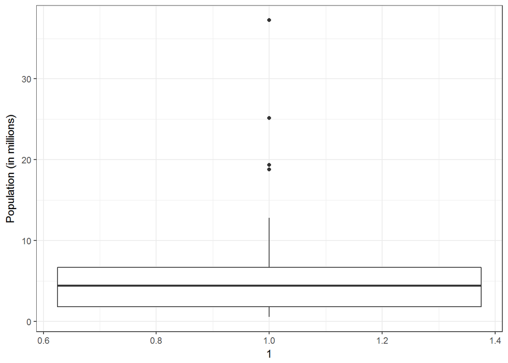

```r
library(ggplot2)
state %>%
  ggplot(aes(1,Population/1000000)) +
  geom_boxplot(varwidth = T) +
  ylab("Population (in millions)") + theme_bw()
```

Whiskers go out to 1.5*IQR and anything outside = outliers plotted as single DP’s

```r
# freq tbl of population by state

# make 11 bins
breaks <- seq(from=min(state$Population),to=max(state$Population),length=11)
# count freq w/ said bins
pop_freq <- cut(state$Population,breaks=breaks,right=T,include.lowest=T)
table(pop_freq)
```

```
## pop_freq
## [5.64e+05,4.23e+06]  (4.23e+06,7.9e+06]  (7.9e+06,1.16e+07]
##                  24                  14                   6
## (1.16e+07,1.52e+07] (1.52e+07,1.89e+07] (1.89e+07,2.26e+07]
##                   2                   1                   1
## (2.26e+07,2.62e+07] (2.62e+07,2.99e+07] (2.99e+07,3.36e+07]
##                   1                   0                   0
## (3.36e+07,3.73e+07]
##                   1
```

```r
#get least + most populous states
state %>%
  filter(Population == min(Population)) %>%
  select(State,Population)
```

```
##     State Population
## 1 Wyoming     563626
```

```r
state %>%
  filter(Population == max(Population)) %>%
  select(State,Population)
```

```
##        State Population
## 1 California   37253956
```

```r
max(state$Population)-min(state$Population) # # of values split into 10 equal-sized bins
```

```
## [1] 36690330
```

```r
(max(state$Population)-min(state$Population))/10 # size of each bin in 10 equal-sized bins
```

```
## [1] 3669033
```

Top bin has ` one state: CA, 2 bins below it = empty, then Texas –> important to include empty bins = useful info

Can also be useful to experiment w/ different bin sizes = if too too large, important features of distribution can be obscured, if too small, result = too granular + ability to see bigger pictures is lost.

Both freq tables + percentiles summarize data via bin, + in general, quartiles + deciles will have same count in each bin (**equal-*count* bins**), but the bin sizes will be different. Freq table, by contrast, has different counts in bins (**equal-*size* bins**).

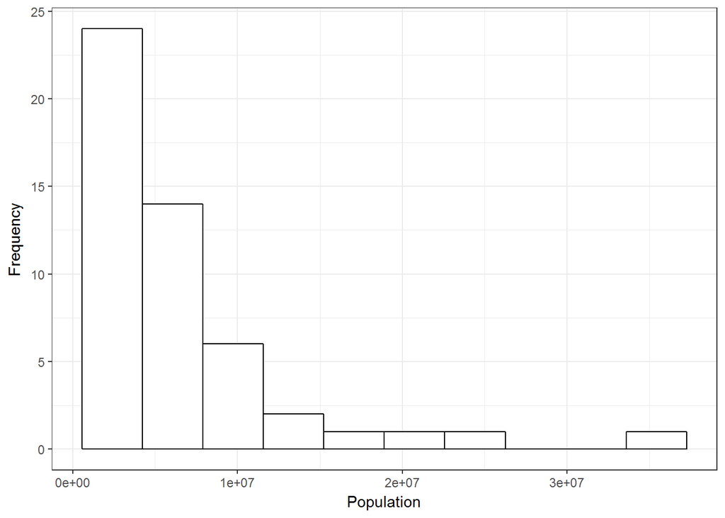

```r
library(ggplot2)
state %>%
  ggplot(aes(Population)) +
  geom_histogram(breaks=breaks,fill='white',color='black') +
  ylab('Frequency') + theme_bw()
```

Again see empty bins included, bins = equal width, # of bins = arbitrary, bars = **contiguous** = no empty spaces between unless bin = empty

In statistical theory, **location** + **variability** = the 1st + 2nd **moments** of a distribution, 3rd + 4th moments = **skewness** + **kurtosis** (propensity of the data to have extreme values) * Generally, metrics = not used to measure skewness and kurtosis + viz displays as used to show/discover them

**Density plot** = distribution of data values as a continuous line. (smoothed histogram) typically computed directly from data through a **kernal density estimate (KDE)**

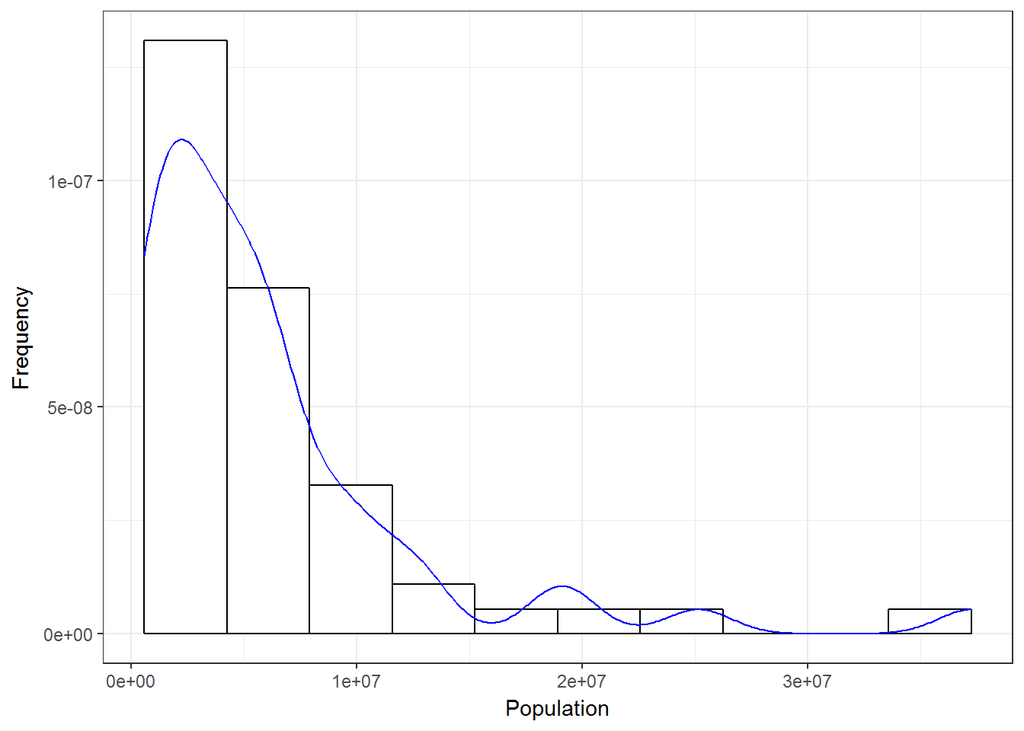

```r
library(ggplot2)
state %>%
  ggplot(aes(Population)) +
  geom_histogram(aes(y = ..density..),breaks=breaks,fill='white',color='black') +
  #geom_density(fill='white',color='blue') +
  geom_line(aes(y = ..density.., colour = 'Empirical'), stat = 'density', color='blue') +
  ylab('Frequency') + theme_bw()
```

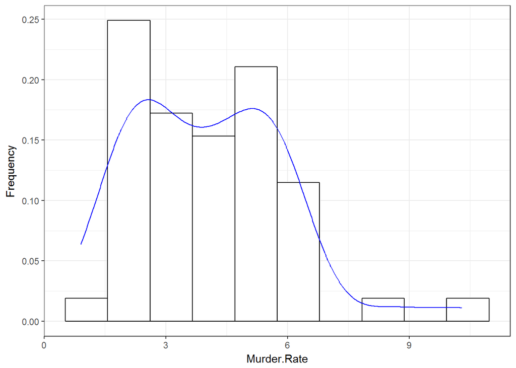

```r
state %>%
  ggplot(aes(Murder.Rate)) +
  geom_histogram(aes(y = ..density..),bins=10,fill='white',color='black') +
  #geom_density(fill='white',color='blue') +
  geom_line(aes(y = ..density.., colour = 'Empirical'), stat = 'density', color='blue') +
  ylab('Frequency') + theme_bw()
```

Alternate plot

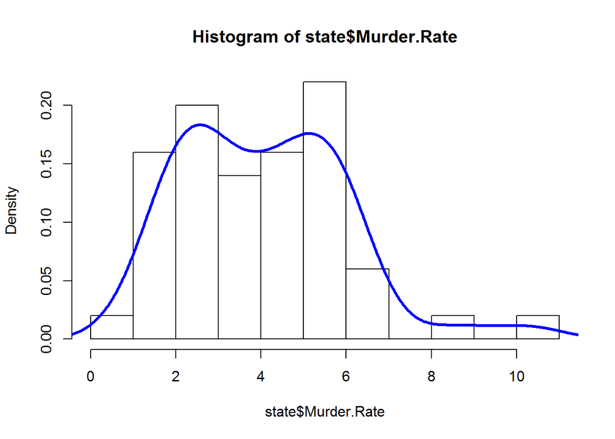

```r
hist(state$Murder.Rate,freq=F) # specify plotting proportion, not counts
lines(density(state$Murder.Rate),lwd=3,col='blue')
```

Density y-axis = plotting histogram as a *proportion* rather than counts.

Density estimation = rich topic w/ long history in statistical literature (20+ R packages have functions for density estimation, w/ particular recommendation for `ASH` or `KernSmooth`, but for many DS problems = suffices to use the base functions.

### Exploring Categorical + Binary Data

Simple proportions + %’s tell the story (mode = useful for categorical, not so much for numerical)

- **Expected Value** = avg. value based on a category’s probability of occurrence (*when categories can be associated with a numeric value*)
- Special type of categorical data = data in which categories represent/be mapped to discrete values on the same scale.
- Ex: New cloud tech = 2 levels of service @ $300/month vs. $50/month, offering free webinars to generate leads, figuring 5% of attendees will sign up for $300 service, 15% for $50, + 80% not sign up for anything.
- This data can be summed up in a single **expected value = form of weighted mean in which weights = probabilities** = multiply each outcome by its probability of occurring + sum these values.
- EV = .05*300 + .15*50 + .8*0 = $22.5/month EV of a webinar attendee is thus $22.50 per month,
- EV adds the ideas of **future expectations and probability weights** often based on *subjective* judgment.
- EV = fundamental concept in business valuation + capital budgeting (ex: EV of 5 years of profits from new acquisition, or expected cost savings from new pt. mgmt. SW @ a clinic)

```r
dfw <- read.csv('../../../../PracticalStatsForDataScientists_50/data/dfw_airline.csv')
# of delays by cause at dallas-fort worth
prop.table(dfw)*100
```

```
##    Carrier      ATC  Weather  Security  Inbound
## 1 23.02299 30.40078 4.025214 0.1229373 42.42808
```

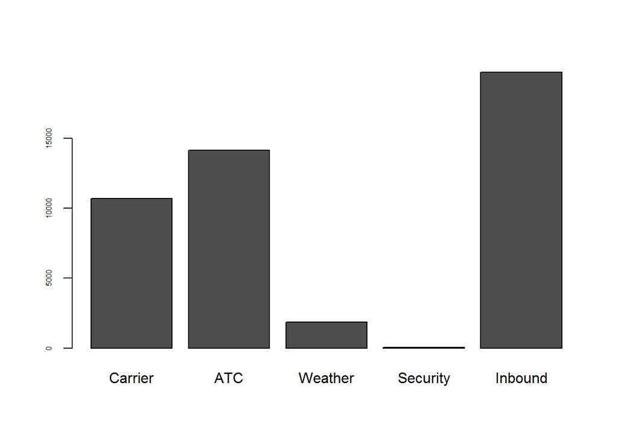

```r
#ggplot() +
#  geom_bar(aes(as.matrix(dfw)))
barplot(as.matrix(dfw)/6, cex.axis=.5)
```

Binning in frequency tables = implicitly converts numeric data to an **ordered factor**

- **Converting numeric data to categorical data = important + widely-used step in data analysis as it reduces complexity (+ size) of data which aids in discovery of relationships between features, particularly @ initial stages of an analysis**

(MISLEADING GRAPHS)[http://passyworldofmathematics.com/misleading-graphs/]

### Correlation

EDA involved looking @ correlations among predictors + between predictors + outcome (high/low, pos/neg)

- Correlation coefficient = r = $\frac {\sum_{i=1}^{N} (x_i - \bar{x})(y_i - \bar{y})} {{N-1} {s_x}{s_y}}$